# HW4

## Praca domowa 4

#### Autor: Wiktor Jakubowski

### Zadanie 1 (1.5 pkt)

Używając funkcji z pakietu `numpy` oraz `pandas` odpowiedz na poniższe pytania dotyczące zbioru danych o grach.

a) Wybierz gry, które zostały wydane po 2015 roku przez Nintendo oraz ich sprzedaż w Ameryce była niższa niż w Europie.

b) Jak rodzaj gry zarobił najwięcej w roku 2010?

c) Jakie typy gier sprzedają się średnio lepiej w Japonii niż w Europie? Jakie to typy gier i jaka jest ta wartość średnia. Wynikiem powinna być tabelka posortowana względem średnich. Nazwij kolumny `Typ Gry` i `Średnia sprzedaż w Japonii`.

```python
import pandas as pd

df = pd.read_csv("https://raw.githubusercontent.com/R-Ladies-Warsaw/PoweR/master/Cz%C4%99%C5%9B%C4%87%202%20-%20Formatowanie%20danych/Python/data/vgsales.csv",
                delimiter = ",").dropna().reset_index(drop = True)
```

```python
# podpunkt a)
df.loc[(df.Year >= 2016.0) & (df.Publisher == "Nintendo") & (df.NA_Sales < df.EU_Sales)].reset_index(drop = True)[["Name"]]
```

|  | Name |
| --- | --- |
| 0 | Mario & Sonic at the Rio 2016 Olympic Games |
| 1 | Mario & Sonic at the Rio 2016 Olympic Games |
| 2 | Teddy Together |

```python
# podpunkt b)
df.loc[df.Year == 2010.0].groupby(df.Genre).Global_Sales.agg("sum").reset_index().sort_values(ascending = False, by = "Global_Sales").head(1)
```

|  | Genre | Global_Sales |
| --- | --- | --- |
| 0 | Action | 117.64 |

```python
# podpunkt c)
df1 = df[["Genre", "JP_Sales", "EU_Sales"]].groupby(df.Genre).mean().reset_index()
df1 = df1.loc[df1.JP_Sales > df1.EU_Sales, ["Genre", "JP_Sales"]].sort_values(ascending = False, by = "JP_Sales").rename(columns = {'Genre' : "Typ Gry",
                     'JP_Sales' : "Średnia sprzedaż w Japonii"})
df1.reset_index(drop = True)
```

|  | Typ Gry | Średnia sprzedaż w Japonii |
| --- | --- | --- |
| 0 | Role-Playing | 0.238293 |
| 1 | Puzzle | 0.099439 |
| 2 | Strategy | 0.073284 |

### Zadanie 2 (3.5 pkt)

Wykorzystując narzędzie do wizualizacji w Pythonie (matplotlib, seaborn) należy poprawić wykres, który był rozwiązaniem pracy domowej 2 (najlepiej poprawić swoją pracę domową, ale można też cudzą).

Rozwiązanie powinno zawierać:

1) oryginalny wykres wraz ze źródłem

2) wykres w ggplot2 wraz z linkiem do pracy domowej w której się on pojawił (kod nie jest potrzebny)

3) poprawiony wykres z punktu 2) w Pythonie

4) uzasadnienie, czemu wykres w Pythonie jest lepszy od dwóch pozostałych.

#### Oryginalny wykres

Postanowiłem zająć się poprawą swojego wykresu z pracy domowej numer 2.

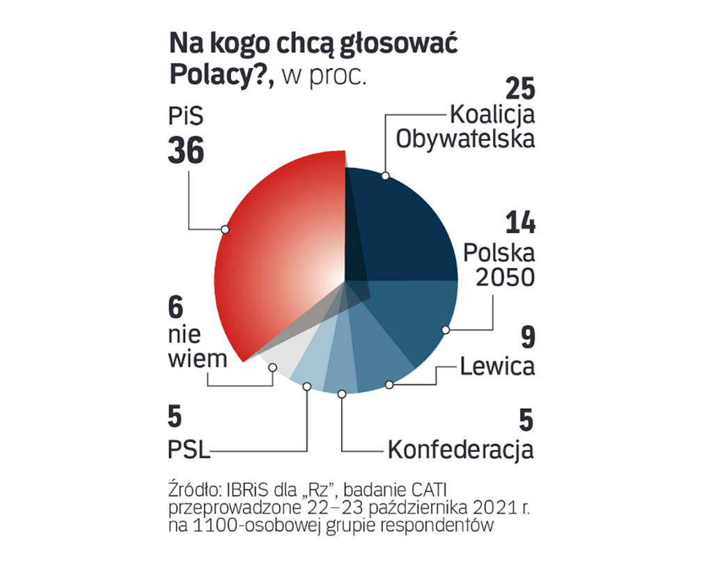

#### Wykres w R ggplot2

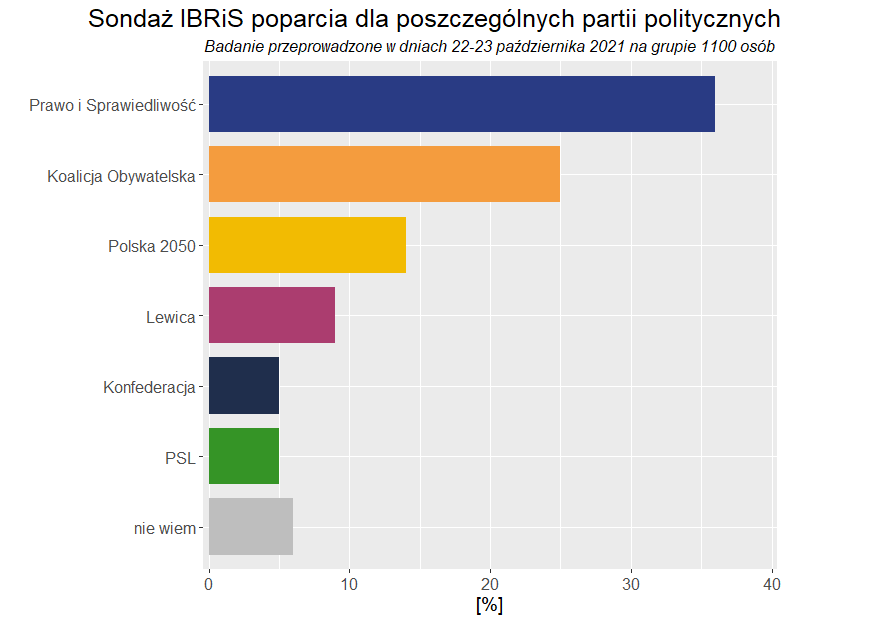

Link do pracy domowej: https://github.com/mini-pw/2022Z-DataVisualizationTechniques/blob/main/homeworks/hw2/JakubowskiWiktor/JakubowskiWiktor.pdf

#### Poprawiony wykres w Pythonie

```python
# import pakietów i danych
import numpy as np
import pandas as pd
import matplotlib.pyplot as plt
import seaborn as sns
df2 = pd.read_csv("dane_IBRIS.csv", encoding = "latin1")
```

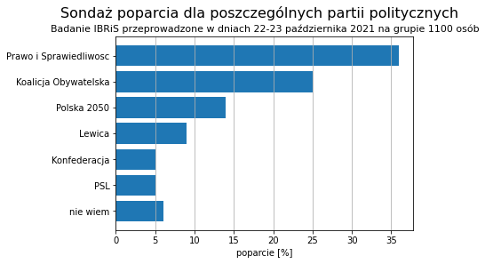

```python
# poprawa wykresu
fig = plt.figure()
ax = fig.add_subplot(1,1,1)
ax.barh(df2["Partia polityczna"], df2["Poparcie w procentach"])
fig.suptitle("Sondaż poparcia dla poszczególnych partii politycznych", fontsize = "16", y = 1)
plt.title("Badanie IBRiS przeprowadzone w dniach 22-23 października 2021 na grupie 1100 osób", fontsize = "11")
ax.set(xlabel = "poparcie [%]",
       ylabel = "")
plt.grid(axis = "x")
plt.show()
```

#### Uzasadnienie

Głównym aspektem, jaki poprawiłem w wykresie w *Pythonie* względem tego z *R ggplot* jest aspekt kolorystyczny. Jako że kolory nie wnosiły żadnych nowych informacji, ich usunięcie jest najlepszym rozwiązaniem. Ponadto, zdecydowałem się na ustawienie jedynie pionowej siatki podziału, gdyż siatka pozioma nie wnosiła żadnej pomocy w odczytywaniu danych, jako że zmienna na osi OY jest jakościowa nominalna.

W porównaniu z wykresem początkowym, zmianie uległy:

- typ wykresu - zastąpienie nieczytelnego wykresu kołowego z elementem 3D wykresem słupkowym w pełni 2D,
- oznaczenia osi - teraz są uporządkowane, nie ma odnosików ze strzałkami, jak w przypadku powyższego wykresu kołowego.